# Statistical Inference Course Project Part2

by jordiac , December 2016

### Synopsis

This is the Course Project of Statistical Inference module from Data Scientist course.

The project aims to analyze the Exponential distribution and compare it with the Normal distribution via 2 main exercises:

```
    1.Simulation exercise
    2.Inferential data analysis
```

### Ex. 2: Inferential data analysis

we’re going to analyze the ToothGrowth data in the R datasets package

-This second exercise shall treat the following points:

```
    1.Perform some basic exploratory data analysis of the data
    2.Provide a basic summary of the data.
    3.Use hypothesis tests to compare tooth growth by supp and dose.
    4.State conclusions and the assumptions needed for conclusions.
```

#### Loading R packages

```r
## *****  Loading libraries ********
library(ggplot2)       #for plotting
```

#### Loading the data

```r
## 2-1) Load ToothGrowth data and perform some basic exploratory data analyses
data("ToothGrowth")
```

#### 1-Basic exploratory analysis

```r
### Dimensions
dim(ToothGrowth)
```

```
## [1] 60  3
```

```r
### Displaying the structure of the data set
str(ToothGrowth)
```

```
## 'data.frame':    60 obs. of  3 variables:
##  $ len : num  4.2 11.5 7.3 5.8 6.4 10 11.2 11.2 5.2 7 ...
##  $ supp: Factor w/ 2 levels "OJ","VC": 2 2 2 2 2 2 2 2 2 2 ...
##  $ dose: num  0.5 0.5 0.5 0.5 0.5 0.5 0.5 0.5 0.5 0.5 ...
```

```r
### Looking at the 6 first rows
head(ToothGrowth)
```

```
##    len supp dose
## 1  4.2   VC  0.5
## 2 11.5   VC  0.5
## 3  7.3   VC  0.5
## 4  5.8   VC  0.5
## 5  6.4   VC  0.5
## 6 10.0   VC  0.5
```

```r
### Range of each numeric variable
range(ToothGrowth$len)
```

```
## [1]  4.2 33.9
```

```r
range(ToothGrowth$dose)
```

```
## [1] 0.5 2.0
```

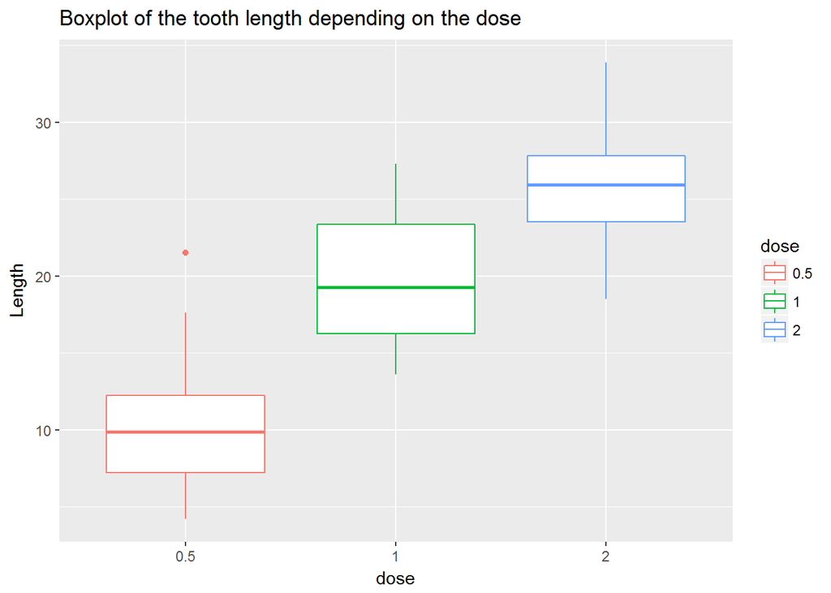

```r
### Converting dose to a factor variable
ToothGrowth$dose <- as.factor(ToothGrowth$dose)

### Visual exploratiry analysis

g3 <- ggplot(ToothGrowth, aes(x= dose, y=len, color= dose))+
        geom_boxplot()+
        labs(title= "Boxplot of the tooth length depending on the dose")+
        labs(x="dose")+
        labs(y="Length")
g3
```

As we can see in this *boxplot*, it seems that tooth length increases with higher dose.

#### 2-Summary of the data

```r
summary(ToothGrowth)
```

```
##       len        supp     dose
##  Min.   : 4.20   OJ:30   0.5:20
##  1st Qu.:13.07   VC:30   1  :20
##  Median :19.25           2  :20
##  Mean   :18.81
##  3rd Qu.:25.27
##  Max.   :33.90
```

#### 3-Hypothesis tests

We will determine with a **5% significance level**, if there is a **correlation** between the dos//supp provided and length of tooth growth.

#### 3-1) Tooth Length depending on Supp group

-*Null Hypothesis H0* : The average length of tooth is **NOT** significantly greater than 0 given the supplementory provided.

-*Alternative Hypothesis Ha* : The average length of tooth is significantly greater than 0 given the supplementory provided.

```r
t1 <- t.test(len~ supp, ToothGrowth)
t1
```

```
##
##  Welch Two Sample t-test
##
## data:  len by supp
## t = 1.9153, df = 55.309, p-value = 0.06063
## alternative hypothesis: true difference in means is not equal to 0
## 95 percent confidence interval:
##  -0.1710156  7.5710156
## sample estimates:
## mean in group OJ mean in group VC
##         20.66333         16.96333
```

As we can see the p-value is 0.0606345 which is greater than 0.05 (5%) so we **failed to reject the null hypothesis (h0)**. In addition, the 95% Confidence interval contains 0, therefore we can say that **there is NOT a significant correlation** between the tooth length growth and the supp provided.

#### 3-2) Tooth Length depending on dose group

-*Null Hypothesis H0* : The average length of tooth is **NOT** significantly greater than 0 given the dose provided.

-*Alternative Hypothesis Ha* : The average length of tooth is significantly greater than 0 given the dose provided.

-Please note that for applying the t.test we need at most 2 different values for dose variable so we have subset the data set depending on dose values:

```r
### We create 3 groups with 2 different dose values each
sub1 <- subset(ToothGrowth, ToothGrowth$dose %in% c(0.5,1))

sub2 <- subset(ToothGrowth, ToothGrowth$dose %in% c(0.5,2))

sub3 <- subset(ToothGrowth, ToothGrowth$dose %in% c(1,2))

### We apply a T.Test
td1<- t.test(len~ dose, sub1)
td2<- t.test(len~ dose, sub2)
td3<- t.test(len~ dose, sub3)

td1
```

```
##
##  Welch Two Sample t-test
##
## data:  len by dose
## t = -6.4766, df = 37.986, p-value = 1.268e-07
## alternative hypothesis: true difference in means is not equal to 0
## 95 percent confidence interval:
##  -11.983781  -6.276219
## sample estimates:
## mean in group 0.5   mean in group 1
##            10.605            19.735
```

```r
td2
```

```
##
##  Welch Two Sample t-test
##
## data:  len by dose
## t = -11.799, df = 36.883, p-value = 4.398e-14
## alternative hypothesis: true difference in means is not equal to 0
## 95 percent confidence interval:
##  -18.15617 -12.83383
## sample estimates:
## mean in group 0.5   mean in group 2
##            10.605            26.100
```

```r
td3
```

```
##
##  Welch Two Sample t-test
##
## data:  len by dose
## t = -4.9005, df = 37.101, p-value = 1.906e-05
## alternative hypothesis: true difference in means is not equal to 0
## 95 percent confidence interval:
##  -8.996481 -3.733519
## sample estimates:
## mean in group 1 mean in group 2
##          19.735          26.100
```

Therefore for 3 subsets the pvalue is quite lower than 0.05 (5%) so we **reject the null Hypothesis (H0)**. In addition, the 95% Confidence intervals **DO NOT** contain 0 for any of the 3 subsets, consequently we can say that **there is a significant correlation** between the tooth length growth and the dose provided.

#### 4-Conclusions

The main assumptions we have made are:

```
 1.The sample used is representative of the population
 2.The sample means distribution follows the Central Limit Theorem
```

Then considering the results obtained in **Part 3** we can conclude that the dose has a significant correlation with the tooth growth but the supp method assigned does not.